# Линейная модель средней стоимости домов в Бостоне

## Общая структура данных

В данной работе проводится построение линейной модели средней стоимости домов (в 1000 долларов) в Бостоне в 1970-1980-х годах на основе данных *Boston*, встроенных в пакет **MASS**. Библиотеки, которые необходимы для выполнения данного проекта **ggplot2**, **dplyr**, **lmtest**, **car**, **gridExtra** и, конечно, **MASS**:

Для начала посмотрим на структуру данных:

```r
str(Boston)
```

```
## 'data.frame':    506 obs. of  14 variables:
##  $ crim   : num  0.00632 0.02731 0.02729 0.03237 0.06905 ...
##  $ zn     : num  18 0 0 0 0 0 12.5 12.5 12.5 12.5 ...
##  $ indus  : num  2.31 7.07 7.07 2.18 2.18 2.18 7.87 7.87 7.87 7.87 ...
##  $ chas   : int  0 0 0 0 0 0 0 0 0 0 ...
##  $ nox    : num  0.538 0.469 0.469 0.458 0.458 0.458 0.524 0.524 0.524 0.524 ...
##  $ rm     : num  6.58 6.42 7.18 7 7.15 ...
##  $ age    : num  65.2 78.9 61.1 45.8 54.2 58.7 66.6 96.1 100 85.9 ...
##  $ dis    : num  4.09 4.97 4.97 6.06 6.06 ...
##  $ rad    : int  1 2 2 3 3 3 5 5 5 5 ...
##  $ tax    : num  296 242 242 222 222 222 311 311 311 311 ...
##  $ ptratio: num  15.3 17.8 17.8 18.7 18.7 18.7 15.2 15.2 15.2 15.2 ...
##  $ black  : num  397 397 393 395 397 ...
##  $ lstat  : num  4.98 9.14 4.03 2.94 5.33 ...
##  $ medv   : num  24 21.6 34.7 33.4 36.2 28.7 22.9 27.1 16.5 18.9 ...
```

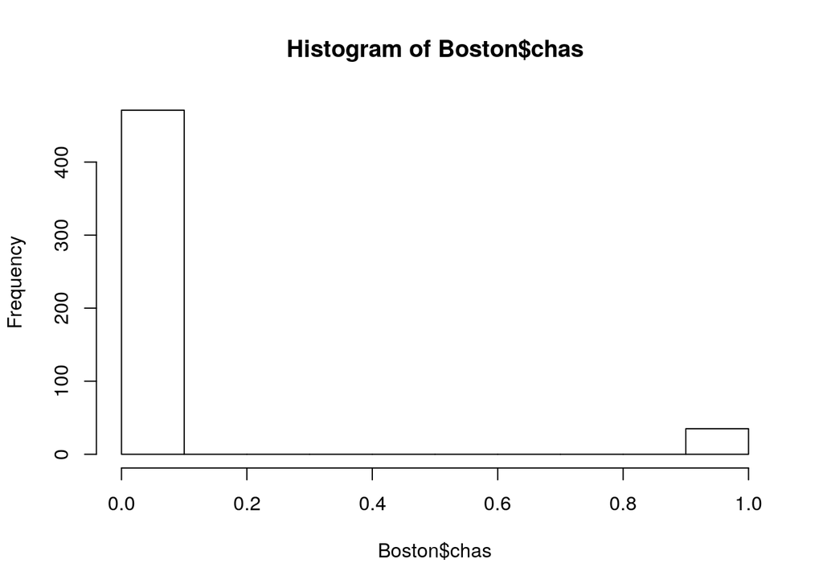

```r
hist(Boston$chas)
```

Переменная *medv* – это как раз средняя стоимость домов в тыс.долларов, *crim* – уровень преступности на душу населения, *zn* – доля жилой земли на участке, *indus* – доля площадей супермаркетов на город, *chas* – близость к реке (1 – рядом, 0 – далеко), *nox* – концентрация оксидов азота, *rm* – среднее количество комнат в доме, *age* – доля старых (до 1940 года) построек, *dis* – средневзвешенное расстояние до 5 бостонских центров занятости, *rad* – индекс доступности к радиальным магистралям, *tax* – налог, *ptratio* – соотношение ученика-учителя, *black* - доля чернокожих, *lstat* – процент малообеспеченных слоев населения.

## 1. Полная линейная модель

Для удобства анализа коэффициентов перед предикторами стандартизуем их:

```r
data <- as.data.frame(sapply(Boston, scale))
```

Построим полную модель.

```r
model_full <- lm(medv ~ ., data)
summary(model_full)
```

```
##
## Call:
## lm(formula = medv ~ ., data = data)
##
## Residuals:
##      Min       1Q   Median       3Q      Max
## -1.69559 -0.29680 -0.05633  0.19322  2.84864
##
## Coefficients:
##               Estimate Std. Error t value Pr(>|t|)
## (Intercept) -1.628e-16  2.294e-02   0.000 1.000000
## crim        -1.010e-01  3.074e-02  -3.287 0.001087 **
## zn           1.177e-01  3.481e-02   3.382 0.000778 ***
## indus        1.534e-02  4.587e-02   0.334 0.738288
## chas         7.420e-02  2.379e-02   3.118 0.001925 **
## nox         -2.238e-01  4.813e-02  -4.651 4.25e-06 ***
## rm           2.911e-01  3.193e-02   9.116  < 2e-16 ***
## age          2.119e-03  4.043e-02   0.052 0.958229
## dis         -3.378e-01  4.567e-02  -7.398 6.01e-13 ***
## rad          2.897e-01  6.281e-02   4.613 5.07e-06 ***
## tax         -2.260e-01  6.891e-02  -3.280 0.001112 **
## ptratio     -2.243e-01  3.080e-02  -7.283 1.31e-12 ***
## black        9.243e-02  2.666e-02   3.467 0.000573 ***
## lstat       -4.074e-01  3.938e-02 -10.347  < 2e-16 ***
## ---
## Signif. codes:  0 '***' 0.001 '**' 0.01 '*' 0.05 '.' 0.1 ' ' 1
##
## Residual standard error: 0.516 on 492 degrees of freedom
## Multiple R-squared:  0.7406, Adjusted R-squared:  0.7338
## F-statistic: 108.1 on 13 and 492 DF,  p-value: < 2.2e-16
```

Рассматривая коэффициенты перед предикторами, можно сделать вывод, что во-первых, значимо наибольший вклад в стоимость вносит коэффициент *lstat*, что очевидно: чем менее благополучные люди живут вокруг, тем в меньшем достатке они находятся, что явно указывает на то, что и жилье рядом будет стоить дешевле, и наоборот (поэтому и коэффициент отрицательный). Несильно отстает по величине вклада предиктор будет *dis* – также понятно почему: вокруг центров занятости живут люди на пособие по безработице, а значит не очень высокого достатка. Почти одинаковый вклад вносят *rm*, *nox*, *tax* и *ptratio*, а за ними по величине вклада *crim*, *zn* и *black*. Заметим, что предикторы *indus* (доля площадей торговых точек), *age* (доля построек до 1940г.) незначимо влияют на значение средней стоимости домов. Этот факт мы будем использовать при редукции нашей модели. Но для начала проведем диагностику полной модели.

### 1.1 Диагностика полной модели

Во-первых, при построении модели в результатах мы можем увидеть значение F-критерия, при помощи которого проверяется гипотеза об отсутствии связи между зависимой переменной и предикторами. Мы получили, что значение F-критерия значимо много больше 1. Это значит, что вероятность получить случайно такое значение связи между предсказываемой величиной и предикторами очень мала, а значит модель в целом должна хорошо описывать наши данные. Также важно посмотреть на скорректированный коэффициент детерминации, в случае полной модели он равен 0.7338, то есть это означает, что наша модель объясняет около 73% дисперсии предсказываемой переменной.

Построим график остатков:

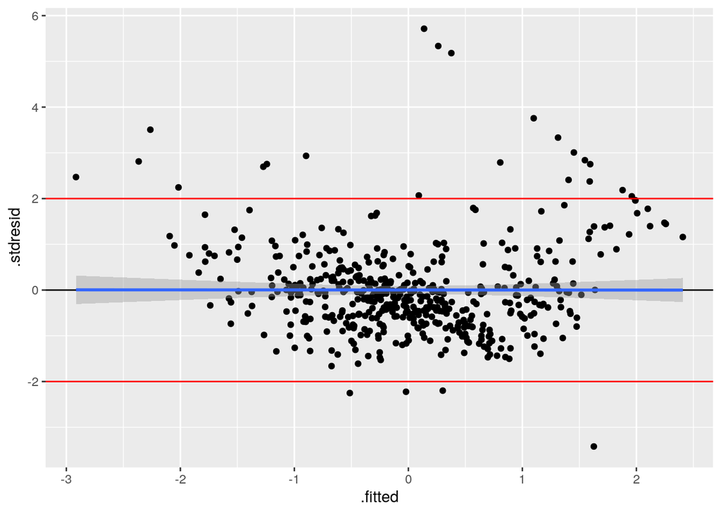

```r
model_full_diag <- data.frame(fortify(model_full), data[])

gg_full <- ggplot(data = model_full_diag, aes(x = .fitted, y = .stdresid)) +
  geom_point() +
  geom_hline(yintercept = 0) +
  geom_smooth(method = "lm") +
  geom_hline(yintercept = 2, color = "red") +
  geom_hline(yintercept = -2, color = "red")
gg_full
```

Остатки в левой и правой части графика имеют в основном только положительные значения, а посередине – отрицательные, что говорит о том, что на самом деле взаимосвязь между предсказываемой переменной и предикторами **не линейна**. Также по графику остатков видно, что в целом, наша модель **гетероскедастична**, то есть ошибки в различных наблюдениях немного скоррелированы. Проверим теперь данный факт численно, применив тест Бройша-Пагана (в более общей формулировке без требования нормальности остатков):

```r
bptest(model_full)
```

```
##
##  studentized Breusch-Pagan test
##
## data:  model_full
## BP = 65.122, df = 13, p-value = 6.265e-09
```

Таким образом, мы отвергаем гипотезу о гомоскедастичности остатков модели. Также по графику остатков можно сделать вывод, что наблюдается какая-то автокорреляция – то есть **наблюдения на самом деле не будут независимыми**.

Построим график Кука:

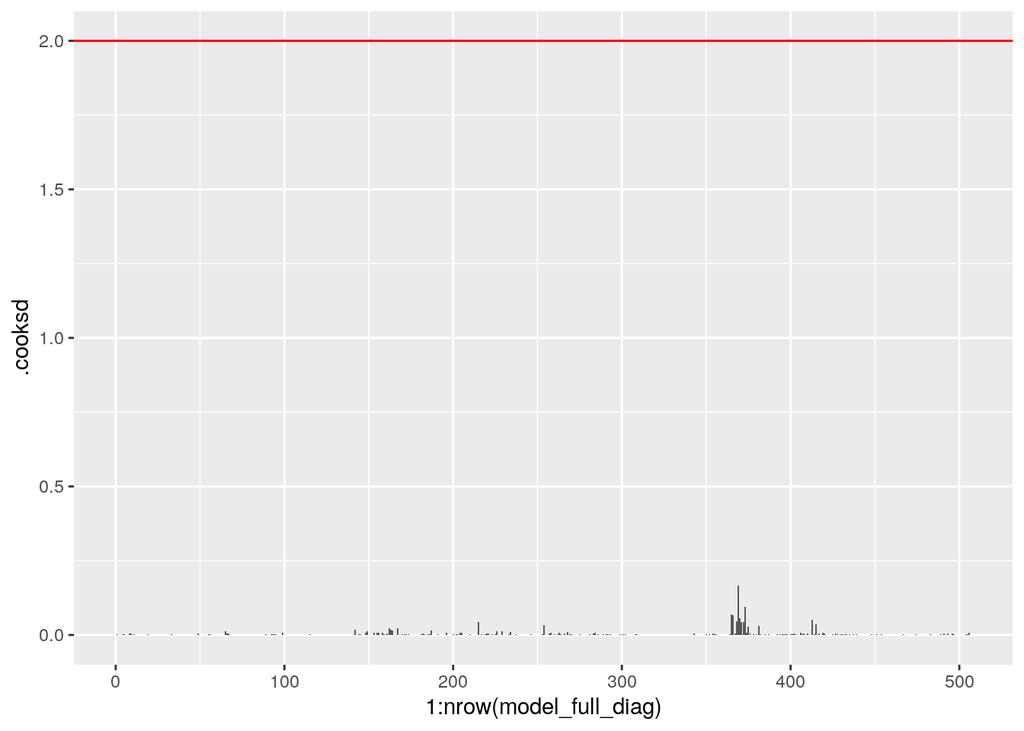

```r
ggplot(model_full_diag, aes(x = 1:nrow(model_full_diag), y = .cooksd)) +
  geom_bar(stat = "identity") +
  geom_hline(yintercept = 2, color = "red")
```

По этому графику можно сделать вывод, что **влиятельных наблюдений в нашем датасете нет**.

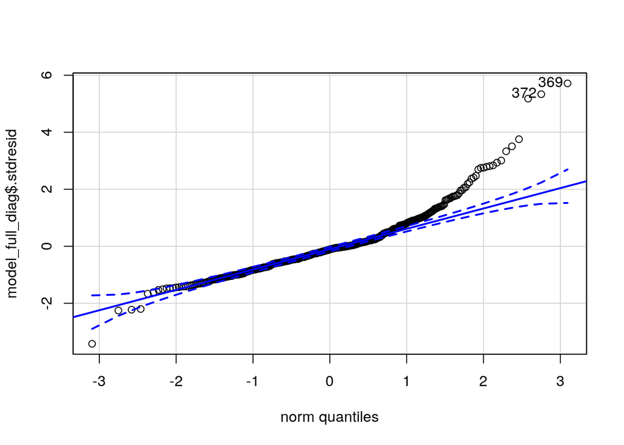

```
## [1] 369 372
```

```r
qqPlot(model_full_diag$.stdresid)
```

Так как точки не легли на одну прямую, то это означает, что остатки **не подчиняются нормальному распределению** (есть хвосты), а **дисперсия непостоянна**.

По совокупности полученных результатов, можем сделать вывод, что несмотря на то, что в целом модель хорошо объясняет дисперсию наблюдений, возможно, нам стоит рассматривать нелинейные модели.